# Predicting Chess Wins based off Openings

By: George Li, Vishal Patel

Contents:

1. Introduction
2. Data
3. Data Cleaning
4. Data Analysis and Visualizations
5. Our Model
6. Result #1
7. Result #2
8. References and Further Reading

```python
import pandas as pd
import numpy as np
import torch
import torch.nn as nn
import torch.nn.functional as F
import torch.optim as optim
import matplotlib.pyplot as plt
import matplotlib.gridspec as gridspec
import seaborn as sns
from torch.utils.data import TensorDataset
from torch.utils.data import DataLoader
from sklearn.model_selection import train_test_split
from sklearn.decomposition import PCA
from google.colab import drive
```

```python
#We have to use Google Collaboratory for the project since our data is too large and we need (free) GPUs
drive.mount('/content/drive')
```

# Introduction

Chess is a two-player board game played by millions around the world. It is known for its complicated nature, which is why understanding it has been considered an interesting problem in computer science for decades. Since there is a finite number of combination of moves, one may think that a computer can just calculate through all combinations and solve the game.

This is unfortunately unfeasible: there are approximately $10^{120}$ possibles combinations of moves. For reference, there are approximatley $10^{80}$ atoms in the universe. By the time a computer calculated all the combinations, Earth would be no more.

Since brute force doesn't work, the obvious next approach is **Machine Learning**. In our project, instead of analyzing the entire chess game, we focus only on the opening, which is generally defined to be the first 20 moves of the game. We want to see whether or not one can use just the opening moves to predict the outcome of a chess game.

The dataset we use is generated from approximately 5 million chess games on lichess.org. The actual dataset was found on Kaggle, which can be found here:

- https://www.kaggle.com/timhanewich/5-million-chess-game-results-november-2019

# Data

Since our dataset is already given to us in a CSV file, we do not have to do any data fetching or pasing. This saves us a lot of time and we can skip directly to the cleaning portion (which we will get to in a bit). First, we will read in our dataset to get an idea as to what it looks it like.

```python
data = pd.read_csv('/content/drive/My Drive/College/CMSC320/data.csv')

print('%d entries with %d labels' % (data.shape[0], data.shape[1]))
data.head(n=5)
```

```
5000995 entries with 30 labels
```

|  | Event | Result | WhiteElo | BlackElo | WhiteRatingDifference | ECO | OpeningName | TimeControl | TimeIncrement | Termination | Move1 | Move2 | Move3 | Move4 | Move5 | Move6 | Move7 | Move8 | Move9 | Move10 | Move11 | Move12 | Move13 | Move14 | Move15 | Move16 | Move17 | Move18 | Move19 | … |
| --- | --- | --- | --- | --- | --- | --- | --- | --- | --- | --- | --- | --- | --- | --- | --- | --- | --- | --- | --- | --- | --- | --- | --- | --- | --- | --- | --- | --- | --- | --- |
| 0 | Rated Rapid tournament https://lichess.org/tou... | 1-0 | 1504.0 | 1505.0 | 7.0 | A00 | Van't Kruijs Opening | 600.0 | 0.0 | Normal | e3 | e5 | b3 | Qf6 | Bb2 | Bd6 | f4 | Nc6 | Nf3 | Nh6 | Bb5 | O-O | Bxc6 | bxc6 | fxe5 | Bxe5 | Bxe5 | Qg5 | O-O | … |
| 1 | Rated Rapid tournament https://lichess.org/tou... | 0-1 | 1487.0 | 1485.0 | -7.0 | B00 | Carr Defense | 600.0 | 0.0 | Normal | e4 | h6 | d4 | a6 | c4 | e6 | e5 | d5 | exd6 | Bxd6 | c5 | Be7 | Nf3 | Nf6 | Be3 | O-O | Bc4 | b5 | Bd3 | … |
| 2 | Rated Rapid tournament https://lichess.org/tou... | 1-0 | 1516.0 | 1523.0 | 13.0 | E36 | Nimzo-Indian Defense: Classical Variation, Noa... | 600.0 | 0.0 | Normal | d4 | Nf6 | c4 | e6 | Nc3 | Bb4 | Qc2 | d5 | a3 | Bxc3+ | Qxc3 | c5 | Nf3 | Nc6 | dxc5 | Bd7 | Bg5 | Rc8 | Bxf6 | … |
| 3 | Rated Blitz tournament https://lichess.org/tou... | 0-1 | 1682.0 | 1666.0 | -8.0 | C78 | Ruy Lopez: Morphy Defense, Neo-Arkhangelsk Var... | 300.0 | 0.0 | Time forfeit | e4 | e5 | Nf3 | Nc6 | Bb5 | a6 | Ba4 | Nf6 | O-O | Bc5 | Re1 | O-O | c3 | b5 | Bc2 | d6 | d4 | Bb6 | Bg5 | … |
| 4 | Rated Blitz tournament https://lichess.org/tou... | 1-0 | 1765.0 | 1766.0 | 7.0 | C50 | Italian Game: Giuoco Pianissimo | 300.0 | 0.0 | Normal | e4 | e5 | Bc4 | Nc6 | Nf3 | Bc5 | d3 | h6 | O-O | Nf6 | c3 | O-O | Be3 | Bb6 | Bxb6 | axb6 | Nbd2 | d6 | h3 | … |

We have quite a few columns, so we will list and describe them here:

# Data Cleaning

The next step is to clean our data. While cleaning data is usually one of the most tedious parts of the data analysis pipeline, it also saves us a lot of time and headaches when we want to perform *actual* analysis, such as visualizations and model training (both of which we will cover later on).

Keep in mind that there is no "one size fits all" step by step guide for data cleaning. But rather, there are certain guidelines or practices that one should follow. The goal of data cleaning is to end up with a tidy dataset that follows some standard (typically defined by your team) and is easy to work with when it comes to visualizing and analyzing.

Here are a couple of the guidelines that we follow when cleaning our hefty chess dataset (along with code-fragments that accomplish each of the cleaning tasks):

#### Removing unnecessary entries or rows

Datasets might include a lot of entries (or rows) that we do not need to look at. Specifically, our dataset contains **two main types of matches: rated (competitive) and correspondence (casual).** Since correspondence matches are less likely to be taken seriously than rated matches, we do not want to muddle our analysis with these "less serious" matches, where players are less likely to be playing at their best ability.

We also do not want to look at **matches where players have cheated.** For example, suppose a lot of players who cheat (and win) tend to use a certain opening. This could potentially bias our analysis in favor of "cheated" openings and lead us to believe that opening is most successful. However, in reality, that opening might not be very successful.

```python
# Dropping rows that aren't rated or timed very well
# https://lichess.org/forum/lichess-feedback/correspondence-rules#4
data = data[~data.Event.str.contains("Correspondence")]

# Dropping matches that violate rules (i.e. cheating)
data = data[data.Termination != 'Rules infraction']

print('%d entries with %d labels' % (data.shape[0], data.shape[1]))
```

```
4991664 entries with 30 labels
```

#### Handling missing data (or empty cells)

Often times, datasets will contain missing data or empty cells. As a result, this can cause unwanted errors, or even bad analysis, later down the road. So it is important to identify places where we have missing data and handle them accordingly (i.e. remove rows with missing data, attempt to impute data, use placeholder values, etc).

Fortunately in our case, most of our data is not missing. Though, there is one entry that is completely null/missing, but that is pretty easy to handle. Other than that, the only places where we have missing data are matches that end in less than 20 moves. Suppose a chess match ends in 13 moves. Then it makes sense that moves 14 through 20 will be "missing" since they cannot possibly exist.

To account for this, we will just remove matches that end in less than 20 moves because the empty moves pose problems later on for us when we train our models.

```python
# Dropping rows that are completely filled with empty values
data.dropna(axis=0, how='all', inplace=True)

# Dropping matches that end in less than 20 moves
data.dropna(subset=['Move'+str(i) for i in range(1,21)], inplace=True)

print('%d entries with %d labels' % (data.shape[0], data.shape[1]))
```

```
4793297 entries with 30 labels
```

#### Converting columns into data types that are easier to work with analytically

Recall that the `Result` column gives us a bunch of strings. This is not super ideal if we want to look at win rates. So, we will convert the `Result` values into numerical values: 1 for a white win, 0 for a black win, and 0.5 for a draw.

```python
# Converting "Result" column into numerical values
# "1-0"     -> win for white
# "0-1"     -> loss for white (or win for black)
# "1/2-1/2" -> draw
# But before we do, make sure we only operate on rows that have
# valid results. An "invalid result" would be "*", which only
# occurs when the match is Unterminated or Abandoned
data = data[data.Result.isin(['1-0','0-1','1/2-1/2'])]
data['Result'] = data.Result.replace({'1-0' : 1, '0-1' : 0, '1/2-1/2' : .5})

print('%d entries with %d labels' % (data.shape[0], data.shape[1]))
data.Result.head(n=5)
```

```
4793274 entries with 30 labels
```

```
0    1.0
1    0.0
2    1.0
3    0.0
4    1.0
Name: Result, dtype: float64
```

#### Splitting up a single column into two or more columns.

Sometimes, a column might contain a bit too much information, so splitting up the column can make our dataset a bit more organized. For example, the `OpeningName` column contains two identifying parts of the opening: the base opening and its variant. In chess, players can make certain moves that identify with a "generalized" (or base) opening. Then their later moves might deviate a bit, and thus identify with a "variant" of their opening. This is particularly important since there can be many combinations of a base opening and variant openings, which can result in lower sample sizes for each combination. As a result, we will split the `OpeningName` column into its base and variant opening, and primarily analyze base openings.

For example, the opening "Italian Game: Giuoco Pianissimo" can be split into its base opening "Italian Game" and its variant "Giuoco Pianissimo".

```python
# Splitting "OpeningName" column into 2 columns: "OpeningBase" and "OpeningVariation"
split_open_names = data.OpeningName.str.split(':', n=1, expand=True)
data['OpeningBase'] = split_open_names[0]
data['OpeningVariation'] = split_open_names[1]
data.drop(columns='OpeningName', inplace=True)

data[['OpeningBase', 'OpeningVariation']].head(n=5)
```

|  | OpeningBase | OpeningVariation |
| --- | --- | --- |
| 0 | Van't Kruijs Opening | None |
| 1 | Carr Defense | None |
| 2 | Nimzo-Indian Defense | Classical Variation, Noa Variation |
| 3 | Ruy Lopez | Morphy Defense, Neo-Arkhangelsk Variation |
| 4 | Italian Game | Giuoco Pianissimo |

#### Renaming columns to be meaningful and concise

Although seemingly trivial, renaming columns provides two main benefits:

1. Clarity of what the column name means
2. Concise so that its easier to write the code

Both of these may not necessarily impact the analysis results, but can make the *process* of analyzing significantly easier and less confusing.

```python
# Renaming a column for ease
data.rename(columns={ 'WhiteRatingDifference': 'WhiteEloDiff' }, inplace=True)

# Re-ordering "Move" columns to be on the far-right
new_columns = [
    'Event', 'Tournament', 'Result', 'Termination',
    'WhiteElo', 'BlackElo', 'WhiteEloDiff', 'AverageElo',
    'TimeControl', 'TimeIncrement', 'AverageTime',
    'ECO', 'OpeningBase', 'OpeningVariation',
]
new_columns += ['Move'+str(i) for i in range(1,21)]
data = data.reindex(columns=new_columns)

print('%d entries with %d labels' % (data.shape[0], data.shape[1]))
data.head(n=5)
```

```
4793274 entries with 34 labels
```

|  | Event | Tournament | Result | Termination | WhiteElo | BlackElo | WhiteEloDiff | AverageElo | TimeControl | TimeIncrement | AverageTime | ECO | OpeningBase | OpeningVariation | Move1 | Move2 | Move3 | Move4 | Move5 | Move6 | Move7 | Move8 | Move9 | Move10 | Move11 | Move12 | Move13 | Move14 | Move15 | … |
| --- | --- | --- | --- | --- | --- | --- | --- | --- | --- | --- | --- | --- | --- | --- | --- | --- | --- | --- | --- | --- | --- | --- | --- | --- | --- | --- | --- | --- | --- | --- |
| 0 | Rated Rapid tournament https://lichess.org/tou... | NaN | 1.0 | Normal | 1504.0 | 1505.0 | 7.0 | NaN | 600.0 | 0.0 | NaN | A00 | Van't Kruijs Opening | None | e3 | e5 | b3 | Qf6 | Bb2 | Bd6 | f4 | Nc6 | Nf3 | Nh6 | Bb5 | O-O | Bxc6 | bxc6 | fxe5 | … |
| 1 | Rated Rapid tournament https://lichess.org/tou... | NaN | 0.0 | Normal | 1487.0 | 1485.0 | -7.0 | NaN | 600.0 | 0.0 | NaN | B00 | Carr Defense | None | e4 | h6 | d4 | a6 | c4 | e6 | e5 | d5 | exd6 | Bxd6 | c5 | Be7 | Nf3 | Nf6 | Be3 | … |
| 2 | Rated Rapid tournament https://lichess.org/tou... | NaN | 1.0 | Normal | 1516.0 | 1523.0 | 13.0 | NaN | 600.0 | 0.0 | NaN | E36 | Nimzo-Indian Defense | Classical Variation, Noa Variation | d4 | Nf6 | c4 | e6 | Nc3 | Bb4 | Qc2 | d5 | a3 | Bxc3+ | Qxc3 | c5 | Nf3 | Nc6 | dxc5 | … |
| 3 | Rated Blitz tournament https://lichess.org/tou... | NaN | 0.0 | Time forfeit | 1682.0 | 1666.0 | -8.0 | NaN | 300.0 | 0.0 | NaN | C78 | Ruy Lopez | Morphy Defense, Neo-Arkhangelsk Variation | e4 | e5 | Nf3 | Nc6 | Bb5 | a6 | Ba4 | Nf6 | O-O | Bc5 | Re1 | O-O | c3 | b5 | Bc2 | … |
| 4 | Rated Blitz tournament https://lichess.org/tou... | NaN | 1.0 | Normal | 1765.0 | 1766.0 | 7.0 | NaN | 300.0 | 0.0 | NaN | C50 | Italian Game | Giuoco Pianissimo | e4 | e5 | Bc4 | Nc6 | Nf3 | Bc5 | d3 | h6 | O-O | Nf6 | c3 | O-O | Be3 | Bb6 | Bxb6 | … |

# Data Analysis and Visualizations

Now that we have cleaned our data thoroughly, we will start analyzing and finding patterns in our data. Although it may not be clear at first, but visualizations play a huge role in discovering patterns. Even something as simple as plotting a frequency distribution of numbers can help us discover a pattern that we would have otherwise overlooked.

There are many ways to visualize your data, and how you do so (once again) depends on your data and what your overarching goal is. In our case, we want to see how openings and the first 20 (or less) moves determine the result of a match. As such, we will start off by looking at the best win rates of base opening names.

```python
# Group rows by their OpeningBase
gb_opening_base = data[['OpeningBase', 'Result']].groupby('OpeningBase')

# Making a new dataframe that uses the opening base as the row id
# and has 3 columns:
# Result - number of columns
# Count - number of matches for the opening base
# WinRate - winrate for White player
opening_base_data = gb_opening_base.sum()
opening_base_data['Count'] = gb_opening_base.size()
opening_base_data['WinRate'] = opening_base_data.Result / opening_base_data.Count
# Dropping rows that have less than 1000 matches
opening_base_data = opening_base_data[opening_base_data.Count >= 1000]

# Setting minimum and maximum y values to plot, which are based
# around the min and max win rates. (used later on)
min_y = opening_base_data.WinRate.min() - 0.01
max_y = opening_base_data.WinRate.max() + 0.01

opening_base_data.head(n=5)
```

| OpeningBase | Result | Count | WinRate |
| --- | --- | --- | --- |
| Alekhine Defense | 26181.0 | 52814 | 0.495721 |
| Alekhine Defense #2 | 1432.0 | 2665 | 0.537336 |
| Amar Opening | 655.5 | 1367 | 0.479517 |
| Amazon Attack | 619.5 | 1377 | 0.449891 |
| Anderssen Opening | 2313.5 | 4638 | 0.498814 |

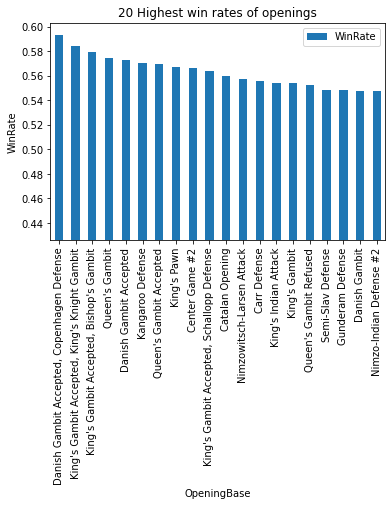

```python
# Plotting 20 highest win rates of openings
obd_highest = opening_base_data.sort_values('WinRate', ascending=False)
obd_highest = obd_highest[:20].reset_index()

obd_highest.plot.bar(x='OpeningBase', y='WinRate',
                    ylim=(min_y, max_y),
                    title='20 Highest win rates of openings',
                    ylabel='WinRate');
```

Looking at our plot, we see that "Danish Gambit Accepted, Copenhagen Defense" appears to be the most successful opening. However, if we take a closer look at the sample sizes for the openings plotted above, we will see something a bit more interesting:

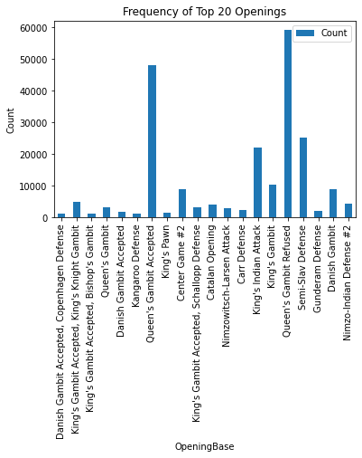

```python
obd_highest.plot.bar(x='OpeningBase', y='Count',
                    title='Frequency of Top 20 Openings',
                    ylabel='Count');
```

It turns out that our "most successful" opening also has one of the sample sizes! So while it is tempting to just look at raw averages, we also need to consider how much data we've collected when we compute that average. In our case, we should take into account how successful an opening is *and* how often we see it.

So now, let's look at how successful the 20 most frequent openings are. That is, we will sort our openings based on how often we see them (the `Count` label), and then plot those win rates.

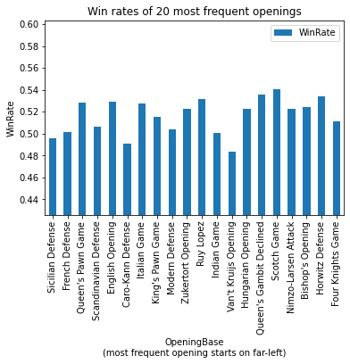

```python
# Plotting 20 largest groups and their win rates
obd_frequent = opening_base_data.sort_values('Count', ascending=False)
obd_frequent = obd_frequent[:20].reset_index()
obd_frequent.plot.bar(x='OpeningBase', y='WinRate',
                      ylim=(min_y, max_y),
                      title='Win rates of 20 most frequent openings',
                      ylabel='WinRate',
                      xlabel='OpeningBase\n(most frequent opening starts on far-left)');
```

We will see that the most common openings' win rates tend to vary between 47% and 55%, which are lower than the highest win rates that we saw earlier; but this is actually a good thing to know!

This lets us know that even though one opening may "appear" to be the best, it might not be very accurate since there are not enough games for this "best" opening. By accounting for each opening's sample size, we can get a better feel for which openings tend to perform better on a much larger scale.

```python
obd_frequent.sort_values('WinRate', ascending=False).iloc[0]
```

```
OpeningBase    Scotch Game
Result               44849
Count                82965
WinRate           0.540577
Name: 15, dtype: object
```

We will also visualize win rates based on the following criterions

1. Average Elo
2. Elo *Difference*
3. Event Type

### Win rates based on Average Elo

We will group matches into 3 different average elo buckets (we will just refer "average elo" simply as "elo"):

1. Beginner: elos less than or equal to 1600
2. Intermediate: elos in between 1500 and 2000 (exclusive range)
3. Expert: elos greater than or equal to 2000

We will then plot the win rates of the 5 most frequent openings for each elo bucket.

```python
# https://matplotlib.org/gallery/api/barchart.html
# Labels the height/values of bars on plots
# Slightly modified to be pretty with decimals
def autolabel(ax, rects, xpos='center'):
    """
    Attach a text label above each bar in *rects*, displaying its height.

    *xpos* indicates which side to place the text w.r.t. the center of
    the bar. It can be one of the following {'center', 'right', 'left'}.
    """

    xpos = xpos.lower()  # normalize the case of the parameter
    ha = {'center': 'center', 'right': 'left', 'left': 'right'}
    offset = {'center': 0.5, 'right': 0.57, 'left': 0.43}  # x_txt = x + w*off

    for rect in rects:
        height = np.around(rect.get_height(), 4)
        ax.text(rect.get_x() + rect.get_width()*offset[xpos], 1.01*height,
                '{}'.format(height), ha=ha[xpos], va='bottom')

# Helper function to plot win rates from multiple dataframes
# n - How many of the largest openings to plot (defaults to 5)
def wr_subplots(dataframes, titles, axs, n=5):
    bars = []
    # Used for setting y-axis limits
    min_y = np.inf
    max_y = -np.inf

    for i in range(len(dataframes)):
        # Group dataframe by opening base
        df = dataframes[i]
        gb = df[['OpeningBase', 'Result']].groupby('OpeningBase')

        # Make new dataframe that uses opening base as row id
        # and has 2 new columns, Count and WinRate
        obd = gb.sum()
        obd['Count'] = gb.size()
        obd['WinRate'] = obd.Result / obd.Count
        # Dropping rows that have less than 1000 matches
        obd = obd[obd.Count >= 1000]

        # Taking 20 most frequent openings for this dataframe
        obd_frequent = obd.sort_values('Count', ascending=False)
        obd_frequent = obd_frequent[:n].reset_index()

        # Adding data to bar plot
        bar_container = axs[i].bar(obd_frequent.OpeningBase, obd_frequent.WinRate)
        axs[i].set_title('Win rates of %d most frequent openings\n%s' % (n, titles[i]))
        axs[i].set_xticklabels(obd_frequent.OpeningBase, rotation=45)

        # Adjust min/max y-values for plots
        # Will reflect these after we go through all dataframes
        min_y = np.minimum(min_y, obd.WinRate.min() - 0.01)
        max_y = np.maximum(max_y, obd.WinRate.max() + 0.01)

        bars.append(bar_container)

    for i in range(len(axs)):
        axs[i].set_ylim(min_y, max_y)

    return bars
```

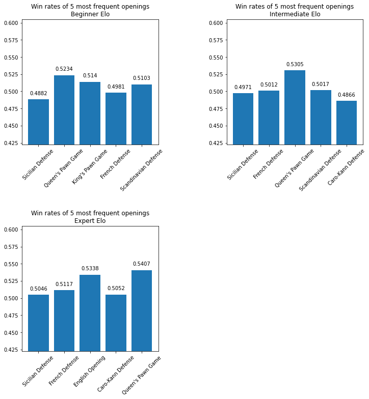

```python
# Adding column for average elo in the match
data['AverageElo'] = .5*data.WhiteElo + .5*data.BlackElo

elo_beginner = data[data.AverageElo<=1600]
elo_intermediate = data[(data.AverageElo>1500) & (data.AverageElo<2000)]
elo_expert = data[data.AverageElo>=2000]

# Setup for laying out plots in a grid
fig1 = plt.figure(figsize=(12,12))
gs1 = gridspec.GridSpec(2, 2, wspace=0.5, hspace=0.65, figure=fig1)
f1_ax1 = fig1.add_subplot(gs1[0, 0])
f1_ax2 = fig1.add_subplot(gs1[0, 1])
f1_ax3 = fig1.add_subplot(gs1[1, 0])
f1_axs = [f1_ax1, f1_ax2, f1_ax3]

bars1 = wr_subplots(
    [elo_beginner, elo_intermediate, elo_expert],
    ['Beginner Elo', 'Intermediate Elo', 'Expert Elo'],
    f1_axs)

# Labeling values of bars
for i in range(len(bars1)):
    autolabel(f1_axs[i], bars1[i])

plt.show()
```

Here, we can notice that regardless of elo, there are 3 common openings:

- Sicilian Defense
- Queen's Pawn Game
- French Defense

Moreover, the Queen's Pawn Game tends to be the most successful amongst these elo groups, with higher win rates from higher-elo games.

### Win rates based on Elo Difference

We can also look at which openings are most successful based on elo difference. The main reason is that we want to see if certain openings are used depending on big of a skill gap there is between the players.

Once again, we will also plot the 5 most frequent openings from each of these difference buckets.

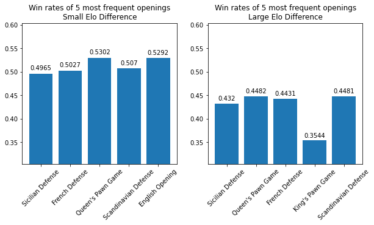

```python
elodiff_small = data[abs(data.WhiteEloDiff)<45]
elodiff_large = data[abs(data.WhiteEloDiff)>=45]

# Setup for laying out plots in a grid
fig2,f2_axs = plt.subplots(ncols=2)
fig2.set_figheight(4.25)
fig2.set_figwidth(10)

bars2 = wr_subplots(
    [elodiff_small, elodiff_large],
    ['Small Elo Difference', 'Large Elo Difference'],
    f2_axs)

for i in range(len(bars2)):
    autolabel(f2_axs[i], bars2[i])

plt.show()
```

From the two plots, we can see that even regardless of the elo difference, they share 4 openings:

- Sicilian Defense
- French Defense
- Queen's Pawn Game
- Scandinavian Defense

Which leaves us with two openings: English Opening and King's Pawn Game. English Opening does not appear to be particularly interesting, but King's Pawn Game tells us a significantly different story since it has a much smaller win-rate than any other opening shown in these plots.

On top of that, games with large elo differences have lower win rates for the common openings when compared with games with small elo differences. One likely explanation for this is that with a small elo difference, both players are closer to each other's skill level and thus more likely to either:

- More accurately predict the other player's moves, or
- Are better equipped (relative to their skill) to deal with certain situations or openings.

### Win rates based on Event Type

Lastly, we will take a look at how win rates for openings compare based on these 4 event types:

- Bullet
- Blitz
- Rapid
- Classical

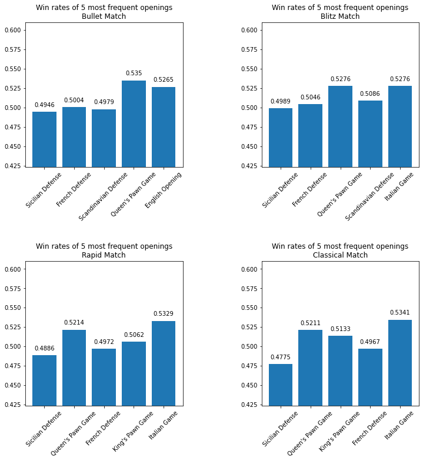

```python
event_bullet = data[data.Event.str.contains("Bullet")]
event_blitz = data[data.Event.str.contains("Blitz")]
event_rapid = data[data.Event.str.contains("Rapid")]
event_classical = data[data.Event.str.contains("Classical")]

# Setup for laying out plots in a grid
fig3 = plt.figure(figsize=(12,12))
gs3 = gridspec.GridSpec(2, 2, wspace=0.5, hspace=0.65, figure=fig3)
f3_ax1 = fig3.add_subplot(gs3[0, 0])
f3_ax2 = fig3.add_subplot(gs3[0, 1])
f3_ax3 = fig3.add_subplot(gs3[1, 0])
f3_ax4 = fig3.add_subplot(gs3[1, 1])
f3_axs = [f3_ax1, f3_ax2, f3_ax3, f3_ax4]

bars3 = wr_subplots(
    [event_bullet, event_blitz, event_rapid, event_classical],
    ['Bullet Match', 'Blitz Match', 'Rapid Match', 'Classical Match'],
    f3_axs)

# Labeling values of bars
for i in range(len(bars3)):
    autolabel(f3_axs[i], bars3[i])

plt.show()
```

Above, we can see that the Sicilian Defense is the most frequent opening used in all types of chess matches, but is also the least the successful.

On the other hand, Queen's Pawn Game has a consistently high win rate across all match types (as well as in small elo differences and all elo ranges); which leads us to believe that it's a good, consistent opening to use in *any* match.

Lastly, there are common openings in most match types:

- All 4 types share Sicilian Defense, French Defense, and Queen's Pawn Game
- Italian Game is common amongst Blitz, Rapid, Classical
- Scandinavian Defense common amongst Bullet, Blitz
- King's Pawn Game common amongst Rapid, Classical

which likely indicates that regardless of the match type, there is still a small handful of openings that are used.

# Garbage Collection

Since we have limited RAM, we need to delete some DataFrames we made previously.

```python
import gc

del gb_opening_base
del opening_base_data
del elo_beginner
del elo_intermediate
del elo_expert
del elodiff_small
del elodiff_large
del event_blitz
del event_bullet
del event_classical
del event_rapid

gc.collect()
```

```
13855
```

# Our Model

The model we will use is a basic linear classifier with a twist. Note that since we are using only the chess moves to predict the result of the chess game, all our predicting variables are categorical variables. Most (if not all) models require predicting variables to be numerical, so we need to represent our moves differently.

The classical way to do this is one-hot encoding, which we talked about in class and you can read more about here. A problem with this is the high number of different chess moves (approximately 2500), causing the input data to be far too large for a machine to handle after the transformation. Another method to handle categorical variables is to use hand-made feature engineering. Though this performs better than one-hot encoding in practice, it takes a lot of time and testing to create sufficiently representative features.

Our idea is motivated from recent-ish developments in natural language processing (NLP) research. The idea is that words are very complicated in nature, so just using one number to represent them doesn't sufficiently encode their meanings. The improvement to one-hot encoding suggested is to use a vector of numbers to represent words, called word embeddings. These high dimensional vectors have empirically done well in representing the meanings of words. Traditionally, the vectors were trained using unsupervised learning methods, but they can also be treated as parameters of the model and optimized using gradient descent.

You can read more about word vectors here:

1. [Efficient Estimation of Word Representations in Vector Space](https://arxiv.org/pdf/1301.3781.pdf)
2. [Global Vectors for Word Representation](https://www.aclweb.org/anthology/D14-1162.pdf)
3. [Pre-training of Deep Bidirectional Transformers for Language Understanding](https://arxiv.org/pdf/1810.04805.pdf)

We apply this idea to chess moves: we create a vector embedding for each chess move. Then we concatenate the 20 vectors, put it through a linear layer, and then apply a softmax. Basically, it is just logistic regression extended to multiclass classification (note: it is multi-class since chess games can be drawn/tied).

```python
class LinearClassifier(nn.Module):

    def __init__(self, input_dim, num_embeddings, output_dim=3, embedding_size = 50):
        super(LinearClassifier,self).__init__()
        self.Embedding = nn.Embedding(num_embeddings, embedding_size)
        self.Linear1 = nn.Linear(input_dim*embedding_size, output_dim)

    def forward(self, x):
        x = self.Embedding(x)
        x = torch.reshape(x,(x.shape[0],-1))
        return self.Linear1(x)
```

## More Data Preparation

Since we are using vector embeddings for our model, we decided to use pytorch. That means, our data preparation takes a lot more work. We first find all the possible (unique) moves that show up in the data. We need this to generate the embeddings.

```python
#list out the predicting variables
predictors = ['Move'+str(i) for i in range(1,21)]

moves = np.array([])

for var in predictors:
    moves = np.append(moves, data[var].unique())

moves = np.unique(moves)
```

In addition, we have to represent all moves with numbers 1, 2, ... , n. This is just the requirement pytorch has on their embeddings module (which is what we're using to implement our model).

We also have to re-encode the results of the games into 0, 1, 2, due to pytorch's implementation for multiclass classification.

```python
moves_dict = {}

for (i,move) in enumerate(moves):
    moves_dict[move] = i

#we have to use just 1 million data samples due to computation and memory limitations
data = data.sample(1000000)

for col in predictors:
    data[col] = data[col].map(moves_dict.get)

#re-encodes the result column: 0 represents win, 1 represents loss, 2 represents draw.
data['Result'] = data['Result'].replace({1 : 0, 0 : 1, .5 : 2})
```

Here, we

1. Split the data into training, testing, and validation data
2. Transform the data into pytorch tensors, which is necessary to train our model.
3. Use pytorch DataLoaders, which batches the data for batch gradient descent.
4. Define the loss function (Cross Entropy) and optimizer (Adam, which is a variant of SGD which converges faster in practice). You can read more about Adam here: https://arxiv.org/pdf/1412.6980.pdf

```python
X = np.array(data[predictors]).astype(int)
Y = np.array(data['Result'])

other_x, test_x, other_y, test_y = train_test_split(X, Y, test_size=.05, random_state=42)
train_x, valid_x, train_y, valid_y = train_test_split(other_x, other_y, test_size=.05, random_state=41)

device = torch.device("cuda" if torch.cuda.is_available() else "cpu")
print(f"{device} is used")

input_size = train_x.shape[1]
model = LinearClassifier(input_size,len(moves))
model.to(device)

train_x_tensor = torch.tensor(train_x, dtype=torch.int64)
train_y_tensor = torch.tensor(train_y, dtype=torch.int64)

train_ds = TensorDataset(train_x_tensor, train_y_tensor)
train_dl = DataLoader(train_ds,
                     batch_size=4096,
                     shuffle=True)

valid_x_tensor = torch.tensor(valid_x, dtype=torch.int64)
valid_y_tensor = torch.tensor(valid_y, dtype=torch.int64)

valid_ds = TensorDataset(valid_x_tensor, valid_y_tensor)
valid_dl = DataLoader(valid_ds,
                     batch_size=4096,
                     shuffle=False)

test_x_tensor = torch.tensor(test_x, dtype=torch.int64)
test_y_tensor = torch.tensor(test_y, dtype=torch.int64)

test_ds = TensorDataset(test_x_tensor, test_y_tensor)
test_dl = DataLoader(test_ds,
                     batch_size=4096,
                     shuffle=False)

#We will be using Adam to train our model and Cross Entropy Loss as our loss function
optimizer = optim.Adam(model.parameters(), lr=.001)
loss_function = nn.CrossEntropyLoss()
```

```
cuda is used
```

## Training

Finally, we train our model. All of this complicated code just performs batch gradient descent.

From the output, we see that the validation starts to go up at the end, even though our loss is going down, which means the model is overfitting a little bit.

```python
train_losses = list()
valid_losses = list()

print("Beginning Training")

epochs = 100

for i in range(epochs):
    model.train()
    train_loss = 0

    #each for loop performs 1 gradient step
    for j, (inputs, targets) in enumerate(train_dl):
        inputs = inputs.to(device)
        targets = targets.to(device)

        optimizer.zero_grad()

        outputs = model(inputs)

        loss = loss_function(outputs, targets)
        loss.backward()

        train_loss += loss.item()

        optimizer.step()

    train_loss /= len(train_dl)

    model.eval()

    valid_loss = 0

    #this calculates the validation loss
    for j, (inputs, targets) in enumerate(valid_dl):

        inputs = inputs.to(device)
        targets = targets.to(device)
        outputs = model(inputs)

        loss = loss_function(outputs, targets)

        valid_loss += loss.item()

    valid_loss /= len(valid_dl)

    train_losses.append(train_loss)
    valid_losses.append(valid_loss)


    print(f"epoch:{i} Training | loss: {train_loss}   Validation | loss: {valid_loss}")

print("Training Complete")
```

```
Beginning Training
epoch:0 Training | loss: 0.851244929689088   Validation | loss: 0.8300138413906097
epoch:1 Training | loss: 0.8313510291177223   Validation | loss: 0.8273342053095499
epoch:2 Training | loss: 0.829361344894133   Validation | loss: 0.8244398385286331
epoch:3 Training | loss: 0.8272377719167131   Validation | loss: 0.8245809028546015
epoch:4 Training | loss: 0.8258747838740974   Validation | loss: 0.8237945983807246
epoch:5 Training | loss: 0.8248658865285675   Validation | loss: 0.8234120061000189
epoch:6 Training | loss: 0.8243774852601651   Validation | loss: 0.8217759927113851
epoch:7 Training | loss: 0.8236572478151969   Validation | loss: 0.821154589454333
epoch:8 Training | loss: 0.8230310551721046   Validation | loss: 0.8204890241225561
epoch:9 Training | loss: 0.8227165139099052   Validation | loss: 0.8212874680757523
epoch:10 Training | loss: 0.8224554490719446   Validation | loss: 0.8205882509549459
epoch:11 Training | loss: 0.8219613055298232   Validation | loss: 0.8210016787052155
epoch:12 Training | loss: 0.8217431948735163   Validation | loss: 0.8207840820153555
epoch:13 Training | loss: 0.8215306514528542   Validation | loss: 0.8199296444654465
epoch:14 Training | loss: 0.8215097660932066   Validation | loss: 0.8216204146544138
epoch:15 Training | loss: 0.8211125890593723   Validation | loss: 0.8201293647289276
epoch:16 Training | loss: 0.8210369531924908   Validation | loss: 0.8193474759658178
epoch:17 Training | loss: 0.8207981513636144   Validation | loss: 0.8204982876777649
epoch:18 Training | loss: 0.8206080090406254   Validation | loss: 0.8192993054787318
epoch:19 Training | loss: 0.8204034040955936   Validation | loss: 0.8212271680434545
epoch:20 Training | loss: 0.8202971389930173   Validation | loss: 0.8202235649029413
epoch:21 Training | loss: 0.8202514575617346   Validation | loss: 0.8198782602945963
epoch:22 Training | loss: 0.8199443593284124   Validation | loss: 0.8202624469995499
epoch:23 Training | loss: 0.820172851981081   Validation | loss: 0.8197243958711624
epoch:24 Training | loss: 0.8197094131918514   Validation | loss: 0.8196205546458563
epoch:25 Training | loss: 0.8196424976732936   Validation | loss: 0.8206055561701456
epoch:26 Training | loss: 0.8195159524274628   Validation | loss: 0.819853792587916
epoch:27 Training | loss: 0.819452473480777   Validation | loss: 0.8195474495490392
epoch:28 Training | loss: 0.8195368140531342   Validation | loss: 0.8198534945646921
epoch:29 Training | loss: 0.8191897413309883   Validation | loss: 0.819845532377561
epoch:30 Training | loss: 0.8190907153608572   Validation | loss: 0.8202197253704071
epoch:31 Training | loss: 0.8191999396587389   Validation | loss: 0.8200705051422119
epoch:32 Training | loss: 0.8190095359923074   Validation | loss: 0.8204636325438818
epoch:33 Training | loss: 0.8188549741360936   Validation | loss: 0.8200840403636297
epoch:34 Training | loss: 0.8187300419915315   Validation | loss: 0.819740871588389
epoch:35 Training | loss: 0.8187169605250811   Validation | loss: 0.81951871017615
epoch:36 Training | loss: 0.8185657270893252   Validation | loss: 0.8199617664019266
epoch:37 Training | loss: 0.8183431628063254   Validation | loss: 0.8210995395978292
epoch:38 Training | loss: 0.8184500644109908   Validation | loss: 0.8197058836619059
```

[output cut: 47 more lines]

```
epoch:86 Training | loss: 0.8148237073043892   Validation | loss: 0.8210097551345825
epoch:87 Training | loss: 0.8147384373311004   Validation | loss: 0.8208094040552775
epoch:88 Training | loss: 0.8147771266790537   Validation | loss: 0.820722684264183
epoch:89 Training | loss: 0.8145493487427138   Validation | loss: 0.8213212986787161
epoch:90 Training | loss: 0.8145217250914595   Validation | loss: 0.821455642580986
epoch:91 Training | loss: 0.8143677859824168   Validation | loss: 0.8213550647099813
epoch:92 Training | loss: 0.8144374149956854   Validation | loss: 0.8214107205470403
epoch:93 Training | loss: 0.8143955968084379   Validation | loss: 0.8209851483503977
epoch:94 Training | loss: 0.8143963535986335   Validation | loss: 0.8215871304273605
epoch:95 Training | loss: 0.8142672191917627   Validation | loss: 0.8220317711432775
epoch:96 Training | loss: 0.8141542780992672   Validation | loss: 0.8216084589560827
epoch:97 Training | loss: 0.8143353985445532   Validation | loss: 0.8212192157904307
epoch:98 Training | loss: 0.8141275798033805   Validation | loss: 0.8211356351772944
epoch:99 Training | loss: 0.8140972356451043   Validation | loss: 0.8216167589028677
Training Complete
```

# Result #1

Finally, we calculate the accuracy of our trained model on the test data. Randomly guessing would yield approximately a 33% accuracy, so as long as the improvement in accuracy is "statistically significant," our model has learned something useful from the data. Indeed, the accuracy is 52.4%, which is a massive improvement.

```python
model.eval()
accuracy = 0

for j, (inputs, targets) in enumerate(test_dl):

  inputs = inputs.to(device)
  targets = targets.to(device)
  outputs = model(inputs)

  #the output is the index which has the largest value, we don't even need to apply a softmax
  choices = torch.argmax(outputs, dim=1)

  #counts the number of correct outputs
  accuracy += torch.eq(choices,targets).sum().item()

accuracy = accuracy/len(test_x)

print(accuracy)
```

```
0.52416
```

# Result #2

In natural language processing research, it has been shown that these vectors represent the meaning of words quite well. For example, the representation of King minus the representation of Man plus the representation of Woman, is actually very very close to the representation of Queen; that is King-Man+Woman=Queen. Towards Data Science has a couple good examples of visualizing word vectors, which you can find here:

- [Visualizing Word Vectors](https://towardsdatascience.com/visualizing-word-embedding-with-pca-and-t-sne-961a692509f5)

We want to see whether we also have these meanings encoded in our embeddings. We test this by visualizing the embeddings, and seeing if there are any patterns. Since our embeddings have very high dimensions (which is hard to visualize), we first reduce the dimensionality using Principal Component Analysis (PCA), into 2 dimensions. Then we plot the different moves onto our classic xy-axis. We only plot a sample of the moves since plotting 2500 moves would just clutter everything.

Unfortunately, there doesn't seem to be any obvious patterns. There are a couple explanations for this. In NLP models, the word vectors are trained on more data and using deep learning (read: a lot of GPU time). Additionally, words naturally have more embedded meaning than a chess move.

Even though we couldn't interpret the embeddings, we showed that chess openings can predict the outcomes of games with accuracy significantly better than random.

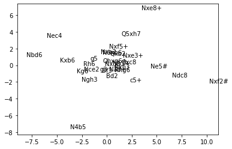

```python
pca = PCA(n_components=2)

params = model.to(torch.device("cpu")).Embedding.weight.detach().numpy()
a = pca.fit_transform(params)
model.to(device)

x = []
y = []

arr = np.array(list(range(2500)))
np.random.shuffle(arr)
arr = list(arr)[:30]

for i in a:
    x.append(i[0])
    y.append(i[1])

fig, ax = plt.subplots()

for i in arr:
  ax.plot(x[i],y[i])
  xy = (x[i],y[i])

  ax.annotate(xy=xy,s=moves[i])

plt.show()
```

# References and Further Reading

1. [Efficient Estimation of Word Representations in Vector Space](https://arxiv.org/pdf/1301.3781.pdf)
2. [Global Vectors for Word Representation](https://www.aclweb.org/anthology/D14-1162.pdf)
3. [Pre-training of Deep Bidirectional Transformers for Language Understanding](https://arxiv.org/pdf/1810.04805.pdf)
4. [Adam: A Method for Stochastic Optimization](https://arxiv.org/pdf/1412.6980.pdf)
5. [Visualizing Word Vectors](https://towardsdatascience.com/visualizing-word-embedding-with-pca-and-t-sne-961a692509f5)